# Kinematic measurement data

Hossain Pezeshki

2015-05-05

# Prompt

I was asked by a firm (as a test) to characterize and describe a given data set `data.csv`. I will be using the following libraries:

```r
library (pracma)  # Matlab like commands for R
library (signal)  # A signal processing toolbox for pracma
```

```r
library (scatterplot3d)
```

# Inspecting the data

The names of the columns in the file suggest that the content consists of periodic measurements generated by an accelerometer and a gyroscope presumably attached to a rigid body. I assume that the objective of such measurements is to infer the **position** and **orientation** of the object. Accordingly, inferring the change in position and in orientation are my aims in this document.

```r
gdat <- read.csv (file="data.csv")
colnames (gdat)
```

```
## [1] "X"        "time"     "accel.x"  "accel.y"  "accel.z"  "rotvel.x"
## [7] "rotvel.y" "rotvel.z"
```

The first column appears to be just the sample number, so I remove it.

```r
gdat <- gdat[,2:8]
```

# Inferring the position of the centre of mass

From elementary mechanics we know that acceleration $a(t)\in R^3$, velocity $v(t) \in R^3$ and position $x(t) \in R^3$ are related as:

$v(t) = v(0) + \int_0^t a(s)\,ds$ $x(t) = x(0) + \int_0^t v(s)\,ds$

Without loss of generality we assume that the object is at rest $v(0)=0$, and is located at the centre of the coordinate system $x(0) = 0\in R^3$. The following code fragment estimates the change in the position and plots it.

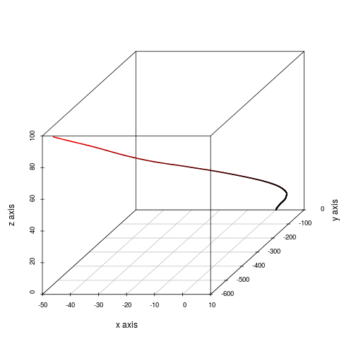

```r
acceleration <- as.matrix (gdat[, c(2:4)])
velocity <- cumtrapz (gdat$time, acceleration)  # Trapezoidal rule approximation of the integrals.
position <- cumtrapz (gdat$time, velocity)
scatterplot3d (position[,1], position[,2], position[,3],
                highlight.3d=TRUE, pch=20, cex.symbols=0.15,
                xlab="x axis", ylab="y axis", zlab="z axis")
```

# Inferring the change in orientation

In this section I am using the online kinematics tutorial found at http://www.euclideanspace.com/physics/kinematics/angularvelocity.

Estimating the orientation is more involved than estimating the position. Let $\omega(t) \in R^3$ be the instantaneous rotational velocity as given in the file. Then the change in orientation is given by an orthogonal **rotation matrix** $D(t) \in R^{3\times3}$ which must be obtained as the solution of the matrix differential equation

$\dfrac{d D(t)}{dt} = W(t)\,D(t)\;\mbox{ subject to } D(0) = \begin{bmatrix} 1 & 0 & 0 \\ 0 & 1 & 0 \\ 0 & 0 & 1 \end{bmatrix}$ where $W(t)$ is a three-by-three matrix which is obtained from instantaneous measured angular velocities $\omega(t)$ as:

$W = \begin{bmatrix} 0 & -\omega_3 & \omega_2 \\ \omega_3 & 0 & -\omega_1 \\ -\omega_2 & \omega_1 & 0 \end{bmatrix}$

The following code fragment performs the $\omega$ to $W$ transformation.

```r
toW <- function (om) {
  tmp <- matrix (data=rep(0,9), nrow=3, ncol=3)
  tmp[1,2] = -om[3]; tmp[1,3] = om[2];
  tmp[2,1] = om[3]; tmp[2,3] = -om[1];
  tmp[3,1] = -om[2]; tmp[3,2] = om[1];
  tmp
}
```

Thus if $u(0)$ is a unit vector indicating the initial orientation of the object, then $D(t) u(0)$ is a **unit vector** that gives the orientation of the object at time $t$.

We now have to solve for $D(t)$. After considering issues of numeric stability I chose the method of **backward Euler** which in the present context becomes:

$D(n\,\Delta t) \approx D((n-1)\,\Delta t) + \Delta t\, W(n\,\Delta t)\, D(n\,\Delta t)$ From which one obtains the implicit $n$’th step approximation as: $D(n\,\Delta t) \approx \left(I - \Delta t\, W(n\,\Delta t)\right)^{-1}\, D((n-1)\,\Delta t)$

In order to further enforce numerical stability, we use the fact that $D$ must be unitary; that is for all $t$ it must be true that $\left(D(t)\right)^{-1} = \left(D(t)\right)^{\top}$.

In my initial experiments I took $\Delta t$ to be the sampling period of the original data , i.e. about $0.047619$ seconds. This, however, proved too coarse (since the $\omega$ measurements are visibly extremely noisy) and the numerical accuracy of my approximate ODE solution failed quickly. Therefore I had to reduce $\Delta t$; but since $\omega$ sampling rate is fixed, the signal must be interpolated. Interpolating signals is well known to DSP engineers whose jargon for it is **up-sampling**. The `signal` package in `R` provides such a function whose mathematical justification can be found at [this Stanford University link](https://ccrma.stanford.edu/~jos/resample/Theory_Ideal_Bandlimited_Interpolation.html). The implementation is given below:

```r
omega <- as.matrix (gdat[,5:7])   # Get the rotational velocities
h <- mean (diff (gdat$time, lag=1)) # The samples are evenly spaced but for tiny variations.
Nobs <- dim (omega)[1]          # The original number of observations

p = 10; q=1;    # omega signal will be interpolated at the rate of p/q
upsomega <- sapply (1:3, function (i) {resample (omega[,i], p, q)})  # upsampled omega

dt = (h * q) / p;  # Delta t is shrunk by q/p
Nup = dim (upsomega)[1]         # The new number of samples

Dt <- list ()
Dt[[1]] <- eye(3)

uptime = vector ("numeric", length = Nup)  # This is the new discrete time axis
uptime[1] = dt;
for (k in 2:Nup) {
  W = toW (upsomega[k,])

  tmp = eye(3) - dt * W
  Dt[[k]] = inv (tmp) %*% Dt[[k-1]]         # Note the backward/implicit Euler
  Dt[[k]] = (1/2) * (Dt[[k]] + inv (t (Dt[[k]])));  # This to ensure D(t) remains unitary

  uptime[k] = dt + uptime[k-1];
}
```

We can now inspect the results by following the action of $D(t)$ on $u(0) = [1,0,0]^\top$.

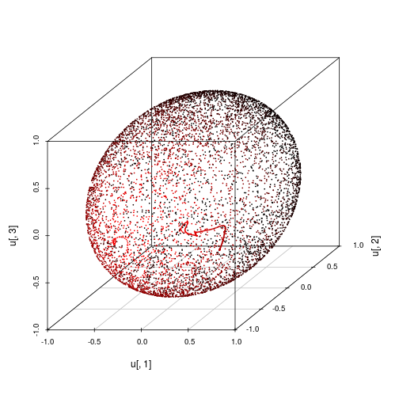

```r
u <- matrix (rep (0.0, 3*Nup), ncol=3)
u[1,] <- c(1,0,0)

for (k in 2:Nup) {
  u[k,] <- Dt[[k]] %*% u[1,]
}

lengths <- sapply (1:dim(u)[1], function (i) {sqrt(t(u[i,]) %*% u[i,])})
u = u / lengths;
scatterplot3d (u[,1], u[,2], u[,3], highlight.3d=TRUE, pch=20, cex.symbols=0.1)
```

Apart from the mass of uniformly distributed noise, one can clearly discern the red curve in the plot, indicating that the above procedure has been able to infer the orientation at least for some of the time. A systems’ level solution to the problem, however, would strive to obtain cleaner less noisy measurements of instantaneous rotational velocities.